# Series Temporales

Yanay

#### Adding libraries

```r
library(readr)
library(dplyr)
library(ggplot2)
library(forecast)
library(lubridate)
library(tseries)
library(pander)
library(lmtest)
```

#### Loading data

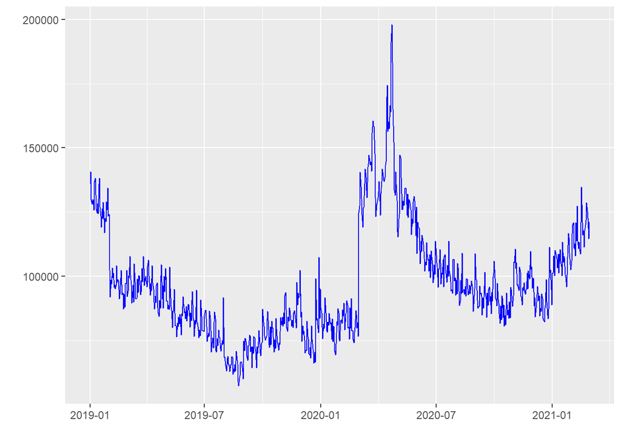

```r
data <- read_csv("C:/Users/yanay/Desktop/Fake Customer Data - Sheet1.csv") %>% as.data.frame()
ggplot(data, aes(Date, Revenue)) + geom_line(colour = "BLUE") + xlab("") + ylab("")
```

#### Transforming data into ts object to use ARIMA models

```r
data1 = data
rownames(data1) = data1$Date
data1$Date=NULL
data_ts <-ts(data1,
             start = c(year(as.POSIXlt(data$Date%>%first(), format="%Y-/%m-/%d")), 1),
             frequency = 365)
```

#### Preparing data:

To fit the ARIMA model, a training window is established whose data are all the values except the 5 months that will be used for testing.

```r
end_date_train <- as.Date(data1%>%rownames()%>%last()) %m-% months(5)
inds <- seq(end_date_train, as.Date(data$Date%>%last()), by = "day")

data.ts_Train = window(data_ts,
                       start=c(year(as.POSIXlt(data$Date%>%first(), format="%Y-/%m-/%d")), 1),
                       end = c( year(end_date_train), as.numeric(format(inds[1], "%j"))),
                       frequency = 365)
```

#### Augmented Dickey-Fuller (ADF) test and ts transformation

A time series has to be stationary for fitting ARIMA models, which means it cannot have a trend and has to have constant variance and autocorrelation structure over time.

If the p-value from the ADF test is less than 0.05, then we can reject the null hypothesis and conclude that the time series is stationary.

Transformations: - Logarithm - Differences

```r
adf_data     <- adf.test(data.ts_Train, alternative = "stationary")$p.value
adf_data_log <- adf.test(log(data.ts_Train), alternative = "stationary")$p.value
adf_data_dif <- adf.test(diff(data.ts_Train), alternative = "stationary")$p.value
```

```r
pander(data.frame(adf_data,adf_data_log,adf_data_dif))
```

| adf_data | adf_data_log | adf_data_dif |
| --- | --- | --- |
| 0.1788 | 0.2648 | 0.01 |

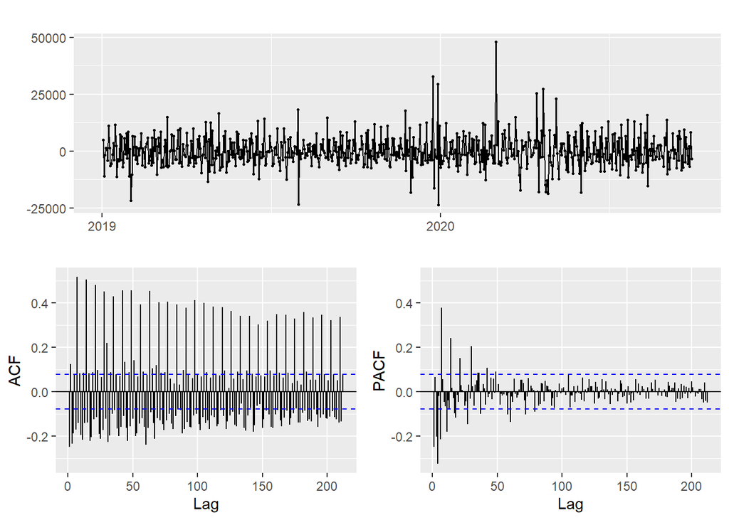

```r
ggtsdisplay(diff(data.ts_Train))
```

After several attempts it seems that the data appear to be an ARIMA(1,1,3), although the ACF and PACF indicators do not have good results.

```r
fit <- Arima(data.ts_Train, order=c(1,1,3), include.drift=TRUE, include.constant = TRUE)
#fit%>%summary()
```

#### Ljung-Box test (or white noise test)

If the p-value from the Ljung-Box test is greater than 0.05, then there is wite noise and the model is well fitted.

```r
LjungBox_test=Box.test(residuals(fit), type="Ljung-Box")$p.value
pander(data.frame(LjungBox_test))
```

| LjungBox_test |
| --- |
| 0.9836 |

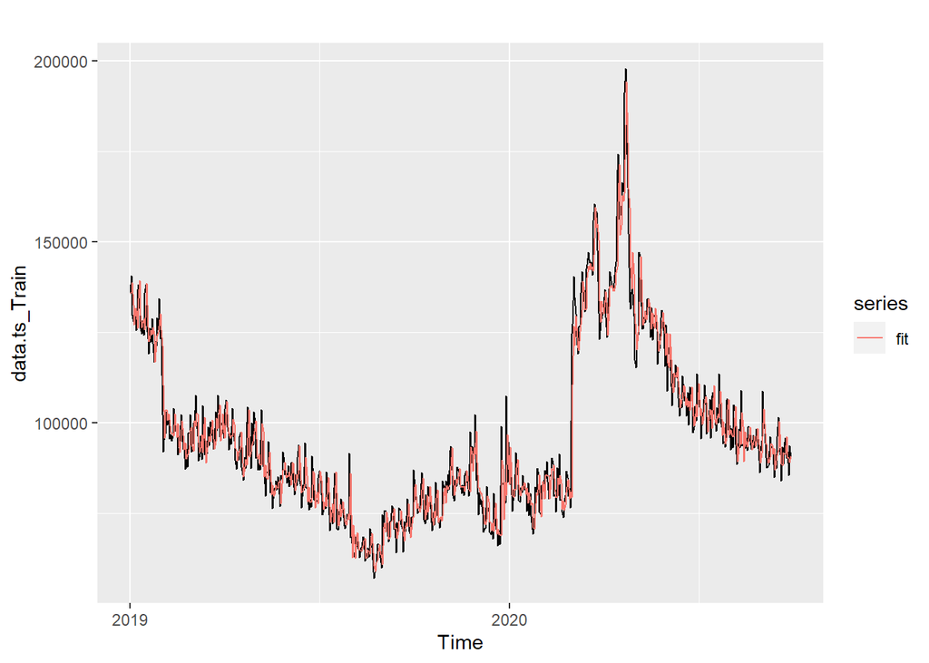

```r
autoplot(data.ts_Train) + autolayer(fit$fitted, series = "fit")
```

As we can see, the ARIMA model fits relatively well with respect to the real data

#### Forcasting

To forecast and test the accuracy of the model, it was saved the last 5 months of the data.

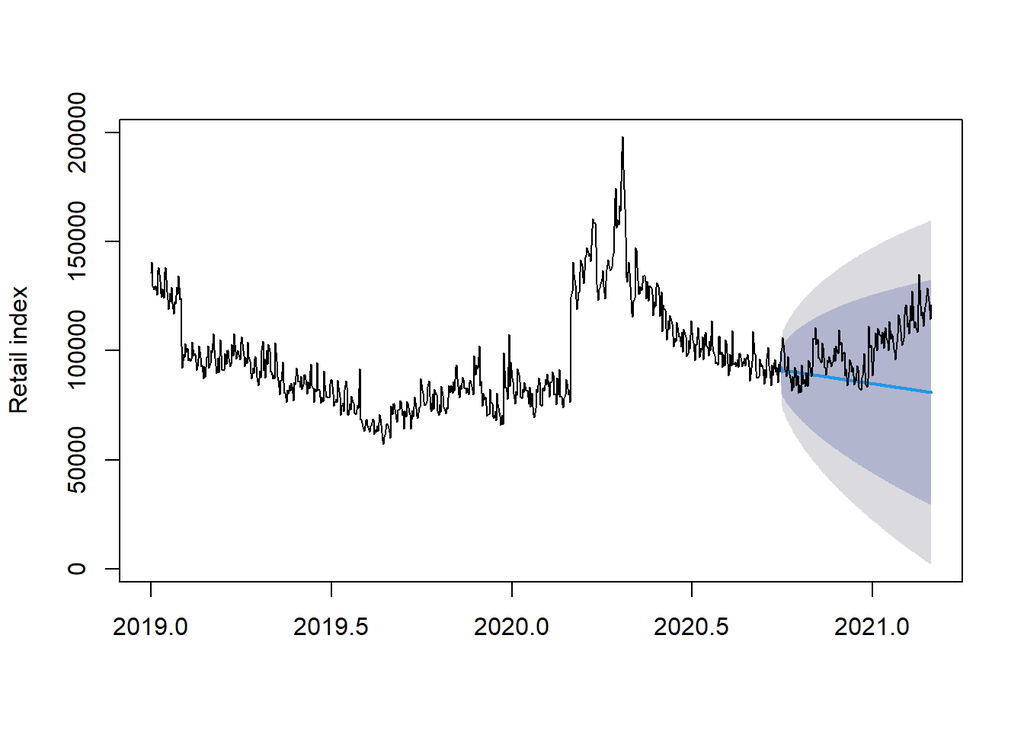

```r
days_to_forecast <- as.numeric( as.Date(data1%>%rownames()%>%last()) - end_date_train )
plot(forecast(fit, h=days_to_forecast), main="", ylab="Retail index")
lines(data_ts, col="black")
```

The results are disappointing, it is necessary to continue looking for other options for the ARIMA model

#### Let's perform now an automatic forecasting

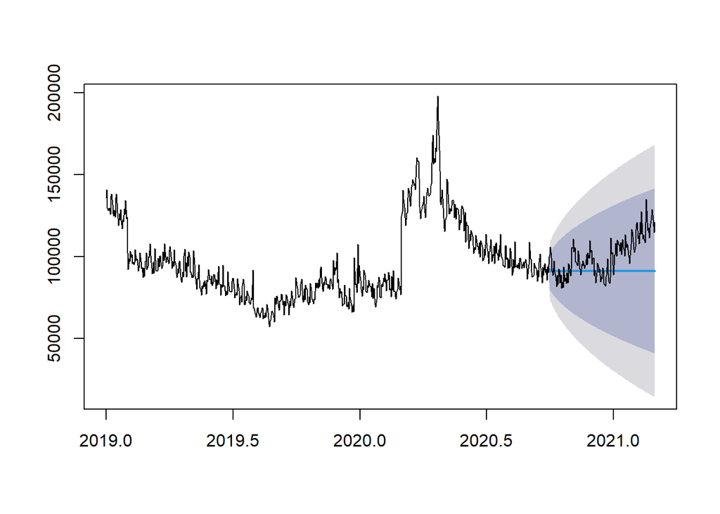

```r
fit <- auto.arima(data.ts_Train, trace = FALSE)
plot(forecast(fit, h=days_to_forecast), main="", ylab="")
lines(data_ts, col="black")
```

The results are a little better but still not good enough.